# Predicting Diabetes In Sub-Populations

David Macy

# Introduction

This investigation will look at three different data sets to predict whether an individual has diabetes or not using logistic regression. Diabetes can be passed down genetically or received based on your lifestyle. According to diabetes.org.uk, “The main difference between the type 1 and type 2 diabetes is that type 1 diabetes is a genetic condition that often shows up early in life, and type 2 is mainly lifestyle-related and develops over time. With type 1 diabetes, your immune system is attacking and destroying the insulin-producing cells in your pancreas”. Type 2 diabetes is when your body stops producing insulin because you have worn out your pancreas. It’s also important to understand that, “For a start, type 1 affects 8% of everyone with diabetes. While type 2 diabetes affects about 90%”(2). Each data set looks at different sub-populations, and has different pieces of data. I will look at each data set individually and create a model for all three data sets.

# Predicting diabetes in the Pima Population

## Visualization of the Data

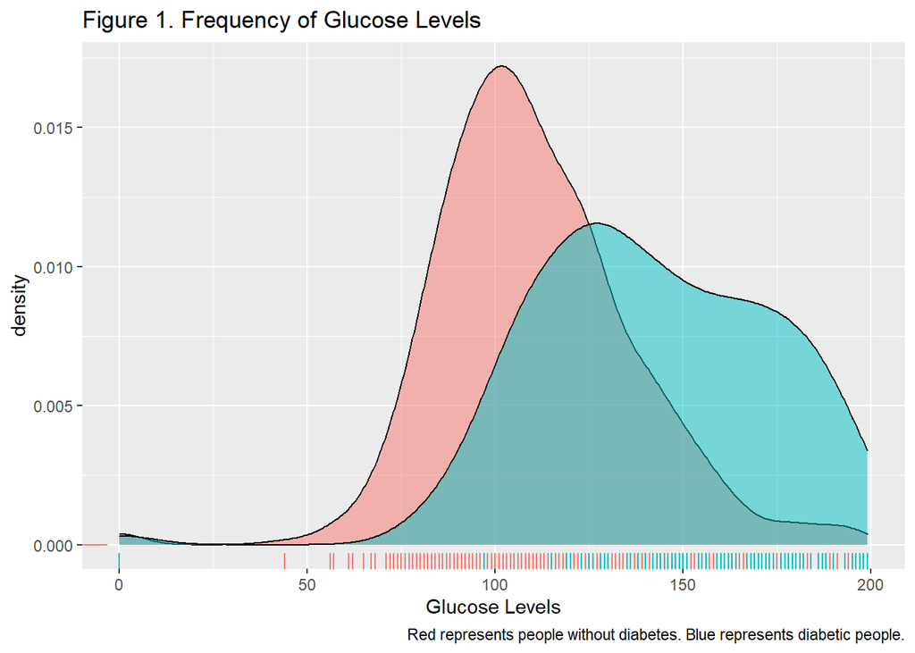

```r
library(tidyverse)
library(kableExtra)
diabetes <- read.csv("diabetesPima.csv")

ggplot(data = diabetes, aes(x = Glucose)) +
  geom_density(aes(fill = as.factor(Outcome)), alpha = 0.5) +
  geom_rug(aes(color = as.factor(Outcome)), y = 0) +
  theme(legend.position = "none") +
  labs(caption = "Red represents people without diabetes. Blue represents diabetic people.", title = "Figure 1. Frequency of Glucose Levels", x = "Glucose Levels")
```

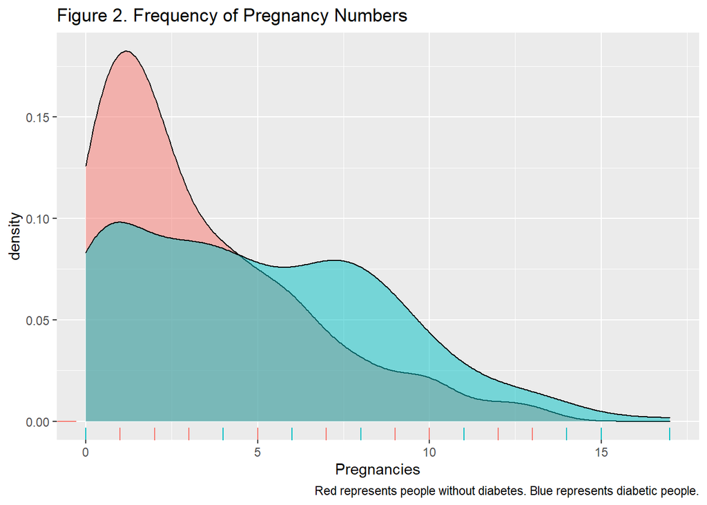

```r
ggplot(data = diabetes, aes(x = Pregnancies)) +
  geom_density(aes(fill = as.factor(Outcome)), alpha = 0.5) +
  geom_rug(aes(color = as.factor(Outcome)), y = 0) +
  theme(legend.position = "none") +
  labs(caption = "Red represents people without diabetes. Blue represents diabetic people.", title = "Figure 2. Frequency of Pregnancy Numbers", x = "Pregnancies")
```

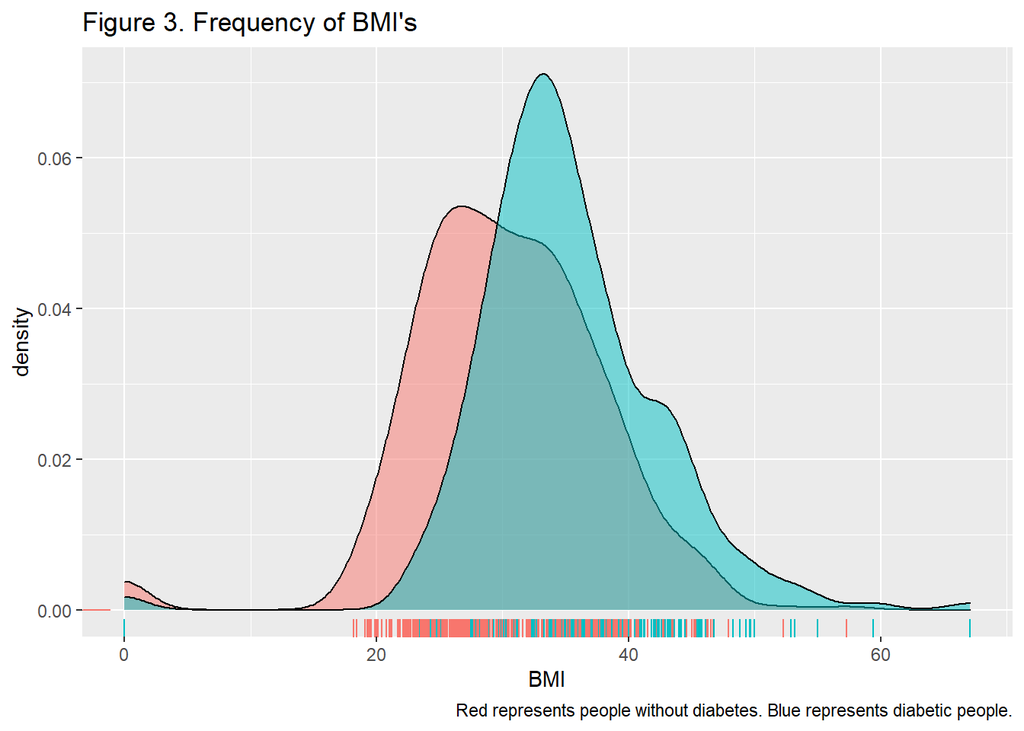

```r
ggplot(data = diabetes, aes(x = BMI), na.rm = TRUE) +
  geom_density(aes(fill = as.factor(Outcome)), alpha = 0.5) +
  geom_rug(aes(color = as.factor(Outcome)), y = 0)  +
  theme(legend.position = "none") +
  labs(caption = "Red represents people without diabetes. Blue represents diabetic people.", title = "Figure 3. Frequency of BMI's", x = "BMI")
```

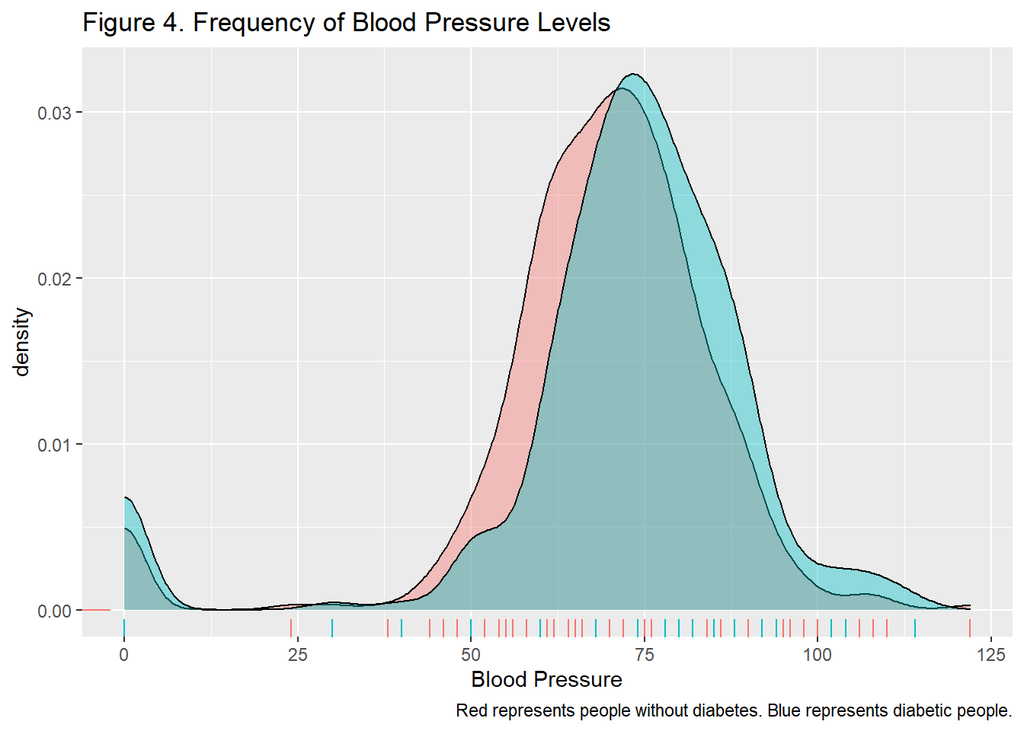

```r
ggplot(data = diabetes, aes(x = BloodPressure)) +
  geom_density(aes(fill = as.factor(Outcome)), alpha = 0.4) +
  geom_rug(aes(color = as.factor(Outcome)), y = 0) +
  theme(legend.position = "none") +
  labs(caption = "Red represents people without diabetes. Blue represents diabetic people.", title = "Figure 4. Frequency of Blood Pressure Levels", x = "Blood Pressure")
```

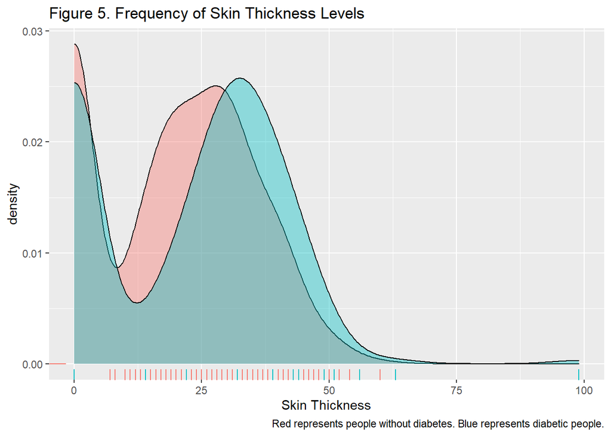

```r
ggplot(data = diabetes, aes(x = SkinThickness)) +
  geom_density(aes(fill = as.factor(Outcome)), alpha = 0.4) +
  geom_rug(aes(color = as.factor(Outcome)), y = 0) +
  theme(legend.position = "none") +
  labs(caption = "Red represents people without diabetes. Blue represents diabetic people.", title = "Figure 5. Frequency of Skin Thickness Levels", x = "Skin Thickness")
```

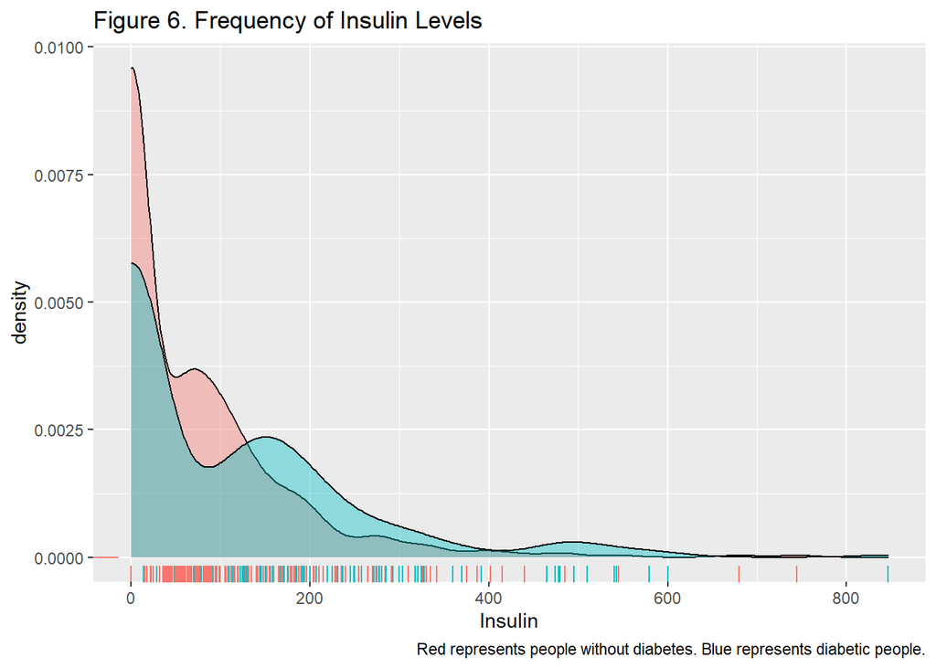

```r
ggplot(data = diabetes, aes(x = Insulin), na.rm = TRUE) +
  geom_density(aes(fill = as.factor(Outcome)), alpha = 0.4) +
  geom_rug(aes(color = as.factor(Outcome)), y = 0) +
  theme(legend.position = "none") +
  labs(caption = "Red represents people without diabetes. Blue represents diabetic people.", title = "Figure 6. Frequency of Insulin Levels", x = "Insulin")
```

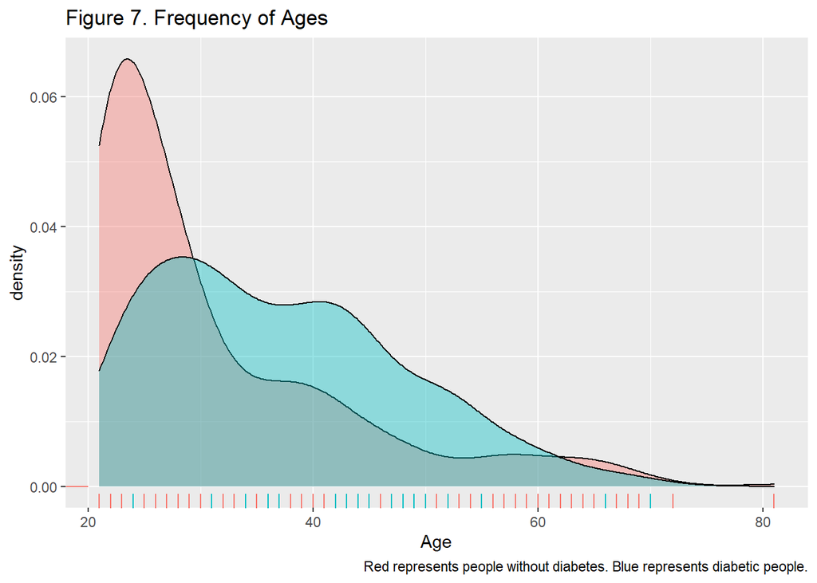

```r
ggplot(data = diabetes, aes(x = Age)) +
  geom_density(aes(fill = as.factor(Outcome)), alpha = 0.4) +
  geom_rug(aes(color = as.factor(Outcome)), y = 0) +
  theme(legend.position = "none") +
  labs(caption = "Red represents people without diabetes. Blue represents diabetic people.", title = "Figure 7. Frequency of Ages", x = "Age")
```

```r
diabetes <- diabetes %>%
  mutate(over30 = ifelse(Age > 30, 1, 0) )
```

## Odds Equation

```r
model <- glm(data = diabetes, Outcome ~  Glucose + over30)
#summary(model)

trainingWPredictions <- diabetes %>%
  mutate(
    training_predictions = predict.glm(model, newdata = diabetes, type = "response"),
    predicted_class = ifelse(training_predictions < 0.5, "Predicted does not have diabetes", "Predicted has diabetes"),
    outcome_class = ifelse(Outcome == "0", "No", "Yes")
  )
```

$OddsDiabetic = e^{-0.497 + 0.00625(GlucoseLevel) + 0.199(Over30YearsOld)}$

This equation shows that the odds of you having diabetes increases depending on your glucose level after the test and whether you are older than 30. To further elaborate, if as your glucose level increases, the higher the odds are that you will have diabetes. If you are older than 30 years old your chance of getting diabetes also increases by the coefficient listed above.

## Confusion Matrix and Success Rate

```r
model <- glm(data = diabetes, Outcome ~  Glucose + over30)
#summary(model)

trainingWPredictions <- diabetes %>%
  mutate(
    training_predictions = predict.glm(model, newdata = diabetes, type = "response"),
    predicted_class = ifelse(training_predictions < 0.375, "Predicted does not have diabetes", "Predicted has diabetes"),
    outcome_class = ifelse(Outcome == "0", "No", "Yes")
  )

confusion_matrix <- table(trainingWPredictions$outcome_class, trainingWPredictions$predicted_class)
kable(confusion_matrix)
```

|  | Predicted does not have diabetes | Predicted has diabetes |
| --- | --- | --- |
| No | 374 | 126 |
| Yes | 71 | 197 |

```r
class_success_rate = sum(diag(confusion_matrix)) / nrow(diabetes)
class_error_rate = 1 - class_success_rate

falsePositive = (126/(389 + 111+84+184))
falseNegative = (71 / (84+389+111+184))
```

Success rate is 0.7434896 while the error rate is 0.2565104. The false positive rate is 0.1640625 while the false negative rate is 0.0924479. The threshold was changed from 50% to a lower number of 37.5% to decrease the number of false negatives. We want to decrease the number of false negatives because giving someone a false negative when they really do have diabetes could be fatal. This slightly hurt the success rate by a percent but it is worth it when peoples lives depend on it.

## Hypothesis Test

```r
SE <- sqrt((0.651*(1 - 0.651)) / nrow(diabetes))

testStatistic = (.76435 - 0.651) / SE
#z = 6.34
#pnorm(z)-gives us probability below a z score
pValue = 1 - pnorm(testStatistic)
```

In this data set 65.1% of people do not have diabetes so our success rate has to be statistically more significant than that value.

# Predicting diabetes with another sub population

For this data set I decided to use the variables of age, family diabetes, and if they regularly use medicine or not. The only data engineering that was needed was to make almost all of the categorical values into factors and to turn the diabetic column into 0 and 1 for predictive purposes.

## Visualizations of the data

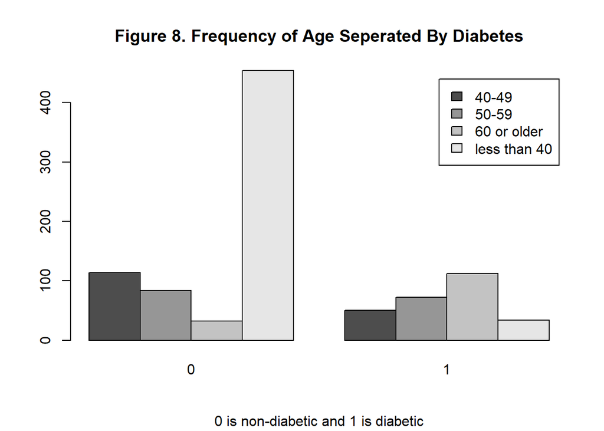

```r
task2 <- read.csv("diabetesTask2.csv")

task2$Age <- as.factor(task2$Age)
task2$Gender <- as.factor(task2$Gender)
task2$FamilyDiabetes <- as.factor(task2$FamilyDiabetes)
task2$highBP <- as.factor(task2$highBP)
task2$PhysicallyActive <- as.factor(task2$PhysicallyActive)
task2$Smoking <- as.factor(task2$Smoking)
task2$Alcohol <- as.factor(task2$Alcohol)
task2$RegularMedicine <- as.factor(task2$RegularMedicine)
task2$JunkFood <- as.factor(task2$JunkFood)
task2$Stress <- as.factor(task2$Stress)
task2$BPLevel <- as.factor(task2$BPLevel)
task2$UriationFreq <- as.factor(task2$UriationFreq)

task2 <- task2 %>%
  mutate(Diabetic = ifelse(Diabetic == "no", 0, 1) )


model <- glm(Diabetic ~ . , data=task2, family = "binomial")
#summary(model)

tbl <- with(task2, table(Age, Diabetic))
barplot(tbl, beside = TRUE, legend = TRUE, main = "Figure 8. Frequency of Age Seperated By Diabetes", sub = "0 is non-diabetic and 1 is diabetic")
```

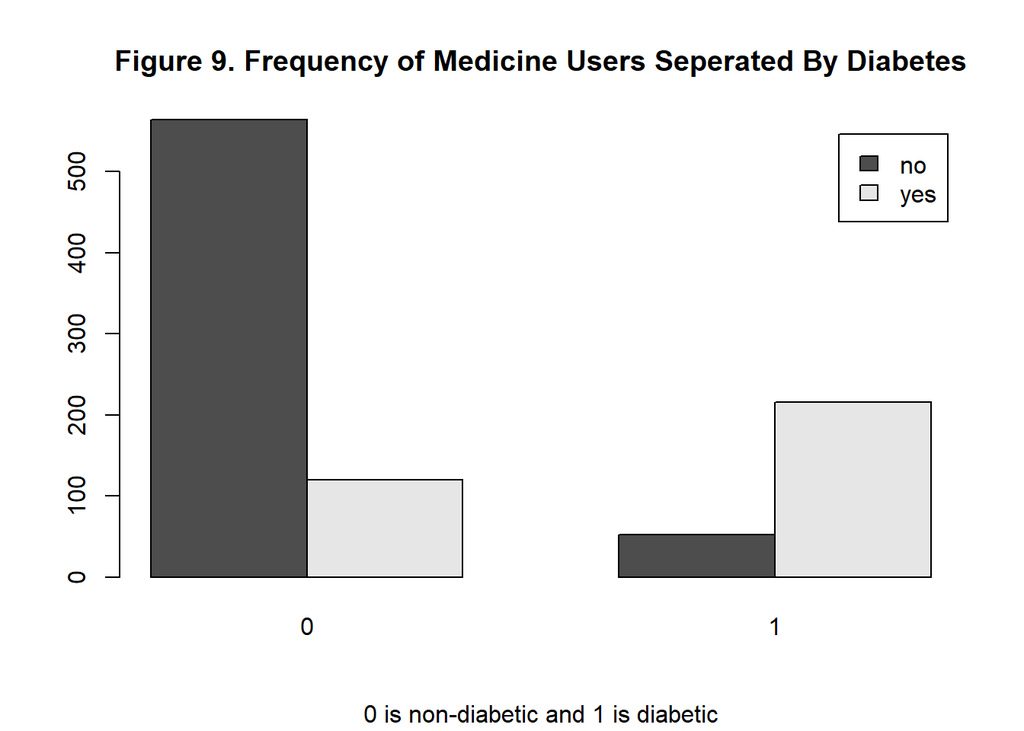

```r
tbl <- with(task2, table(RegularMedicine, Diabetic))
barplot(tbl, beside = TRUE, legend = TRUE, main = "Figure 9. Frequency of Medicine Users Seperated By Diabetes", sub = "0 is non-diabetic and 1 is diabetic")
```

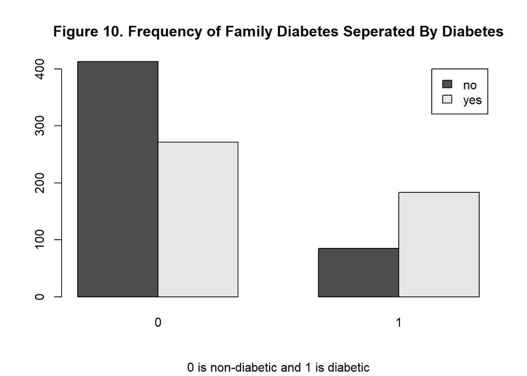

```r
tbl <- with(task2, table(FamilyDiabetes, Diabetic))
barplot(tbl, beside = TRUE, legend = TRUE, main = "Figure 10. Frequency of Family Diabetes Seperated By Diabetes", sub = "0 is non-diabetic and 1 is diabetic")
```

## Model

```r
model <- glm(Diabetic ~ RegularMedicine + Age + FamilyDiabetes, data=task2, family = "binomial")
#summary(model)

trainingWPredictions <- task2 %>%
  mutate(
    training_predictions = predict.glm(model, newdata = task2, type = "response"),
    predicted_class = ifelse(training_predictions < 0.3, "Predicted does not have diabetes", "Predicted has diabetes"),
    outcome_class = ifelse(Diabetic == "0", "No", "Yes")
  )
```

$OddsDiabetic = e^{-2.69 + 2.19(yesMedicine) + 0.37(Age50-59) + 1.88(AgeGreater60) - 1.29(AgeLess40) + 1.32(yesFamilyDiabetes)}$

This model says that regularly taking medicine, ages 50 and older, and history of family diabetes increase the odds having diabetes while having an age less than 40 decreases the odds of having diabetes.

## Confusion Matrix and Success Rates

```r
model <- glm(Diabetic ~ RegularMedicine + Age + FamilyDiabetes, data=task2, family = "binomial")
#summary(model)

trainingWPredictions <- task2 %>%
  mutate(
    training_predictions = predict.glm(model, newdata = task2, type = "response"),
    predicted_class = ifelse(training_predictions < 0.3, "Predicted does not have diabetes", "Predicted has diabetes"),
    outcome_class = ifelse(Diabetic == "0", "No", "Yes")
  )
confusion_matrix <- table(trainingWPredictions$outcome_class, trainingWPredictions$predicted_class)
kable(confusion_matrix)
```

|  | Predicted does not have diabetes | Predicted has diabetes |
| --- | --- | --- |
| No | 577 | 107 |
| Yes | 38 | 230 |

```r
class_success_rate = sum(diag(confusion_matrix)) / nrow(task2)
class_error_rate = 1 - class_success_rate

falsePositive = 107 / (577 + 38  + 230 + 107)
falseNegative = 38 / (577 + 38 + 230 + 107)
```

Success rate is 0.8476891 while the error rate is 0.1523109. The false positive rate is 0.112395 while the false negative rate is 0.039916. The threshold was changed to 30% to decrease the number of false negatives because giving someone a false negative when they really do have diabetes could be fatal. As stated before, changing the threshold slightly hurts the success rate by a percent or two but is necessary in this case.

## Hypothesis Test

```r
SE <- sqrt((0.7185*(1 - 0.7185)) / nrow(task2))

#For Glucose
testStatistic = (0.8477 - 0.7185) / SE
#z = 8.569
#pnorm(z)-gives us probability below a z score
pValue = 1 - pnorm(testStatistic)
#This p - value is 0
```

In this data set 71.85% of people do not have diabetes so our success rate has to be statistically more significant than that value.

The test statistic is 8.8639725 while the p - value is 0. Our model with a success rate of 84.77% is statistically more significant than the null hypothesis of 71.85% according to the p - value reported.

# Predicting diabetes with the BRFSS data

For this data set I decided to start of by using the variables of age, general health, sex, high blood pressure, high cholesterol, BMI, if they had a cholesterol test done, and if they had heart disease or attack. The only data engineering that was needed was to make almost all of the categorical values. This gets modified after looking at the visualizations.

## Visualizations

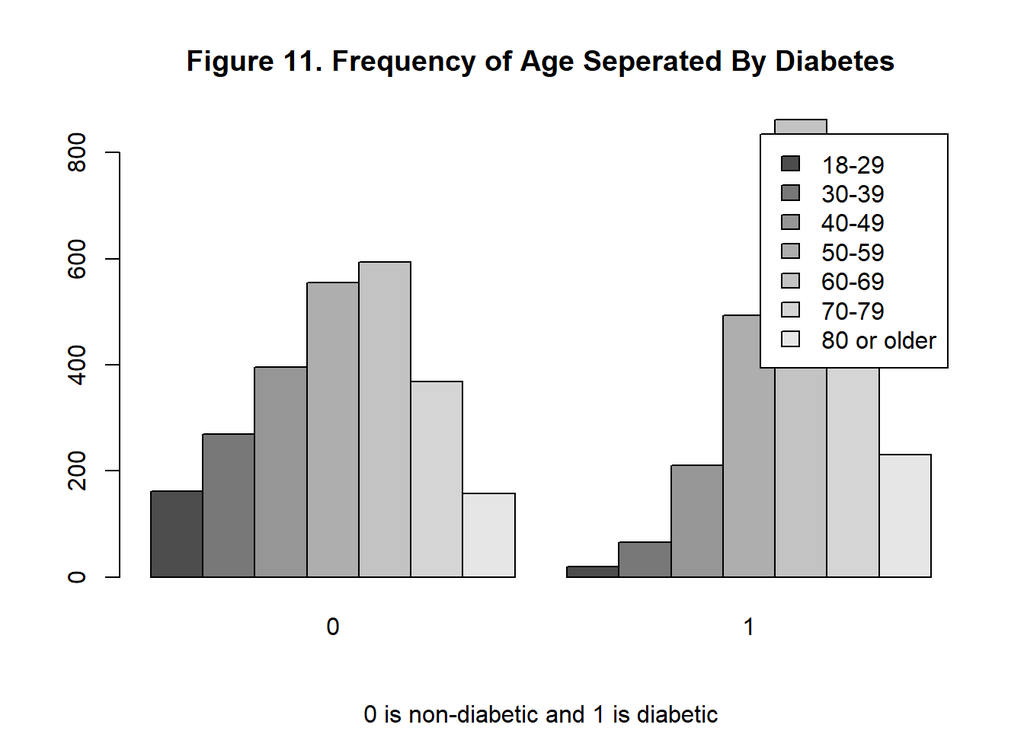

```r
task3 <- read.csv("diabetesTask3Given.csv")
task3$HighBP <- as.factor(task3$HighBP)
task3$CholCheck <- as.factor(task3$CholCheck)
task3$Smoker <- as.factor(task3$Smoker)
task3$Stroke <- as.factor(task3$Stroke)
task3$HeartDiseaseorAttack <- as.factor(task3$HeartDiseaseorAttack)
task3$PhysActivity <- as.factor(task3$PhysActivity)
task3$Fruits <- as.factor(task3$Fruits)
task3$Veggies <- as.factor(task3$Veggies)
task3$HvyAlcoholConsump <- as.factor(task3$HvyAlcoholConsump)
task3$AnyHealthcare <- as.factor(task3$AnyHealthcare)
task3$NoDocbcCost <- as.factor(task3$NoDocbcCost)
task3$GeneralHealth <- as.factor(task3$GeneralHealth)
task3$MentHlth <- as.factor(task3$MentHlth)
task3$PhysHlth <- as.factor(task3$PhysHlth)
task3$DiffWalk <- as.factor(task3$DiffWalk)
task3$Sex <- as.factor(task3$Sex)
task3$HighChol <- as.factor(task3$HighChol)
task3$Education <- as.factor(task3$Education)
task3$Income <- as.factor(task3$Income)
task3$age <- as.factor(task3$age)

tbl <- with(task3, table(age, Diabetes_binary))
barplot(tbl, beside = TRUE, legend = TRUE, main = "Figure 11. Frequency of Age Seperated By Diabetes", sub = "0 is non-diabetic and 1 is diabetic")
```

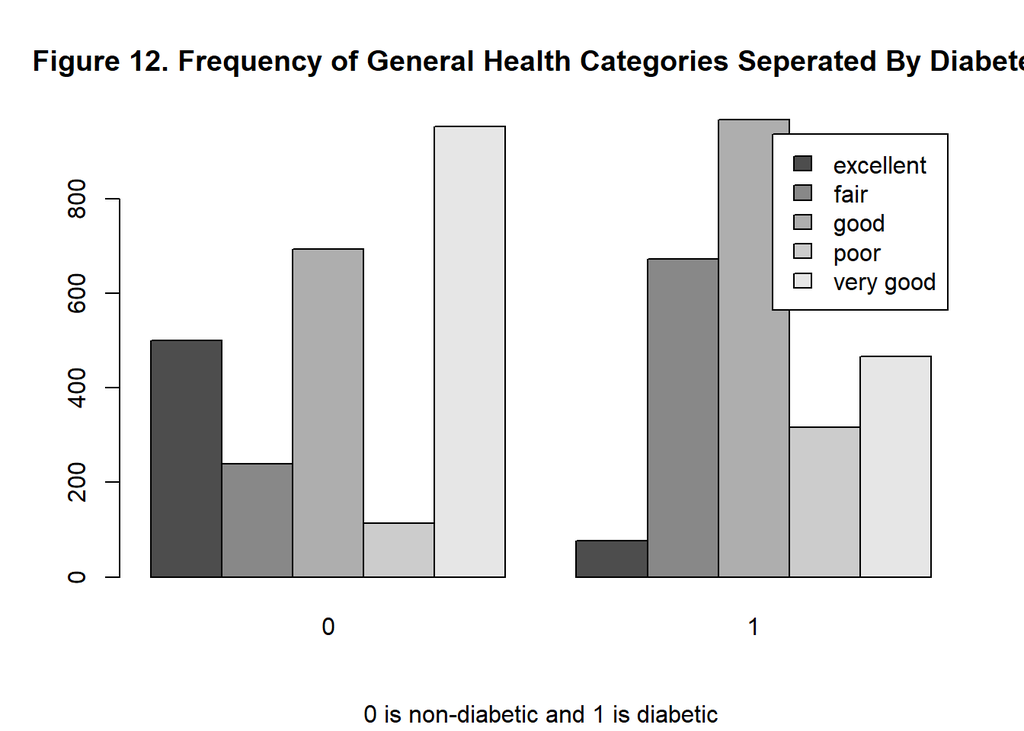

```r
tbl <- with(task3, table(GeneralHealth, Diabetes_binary))
barplot(tbl, beside = TRUE, legend = TRUE, main = "Figure 12. Frequency of General Health Categories Seperated By Diabetes", sub = "0 is non-diabetic and 1 is diabetic")
```

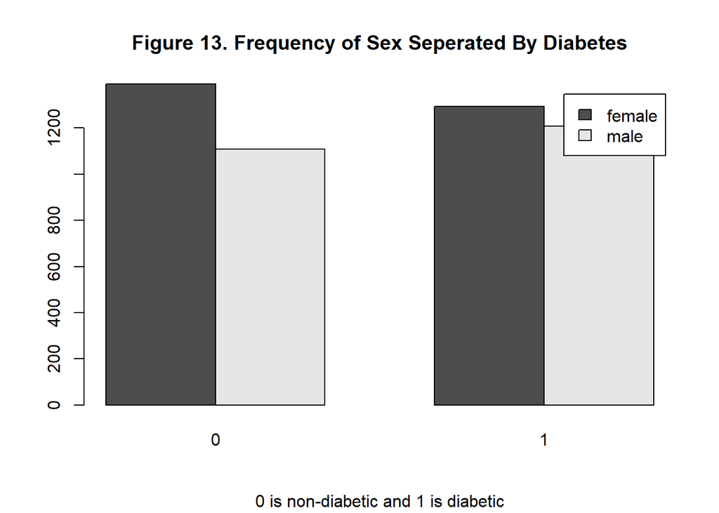

```r
tbl <- with(task3, table(Sex, Diabetes_binary))
barplot(tbl, beside = TRUE, legend = TRUE, main = "Figure 13. Frequency of Sex Seperated By Diabetes", sub = "0 is non-diabetic and 1 is diabetic")
```

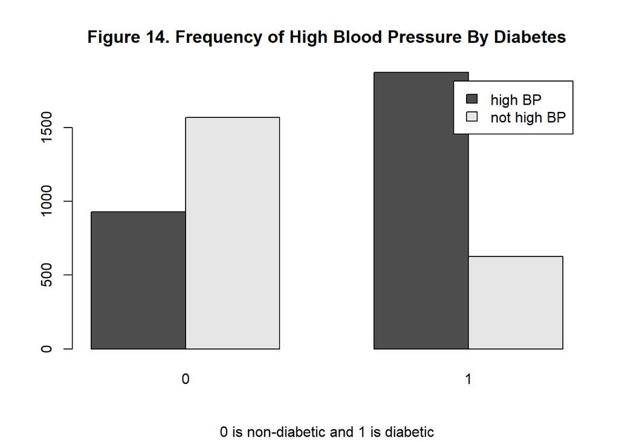

```r
tbl <- with(task3, table(HighBP, Diabetes_binary))
barplot(tbl, beside = TRUE, legend = TRUE, main = "Figure 14. Frequency of High Blood Pressure By Diabetes", sub = "0 is non-diabetic and 1 is diabetic")
```

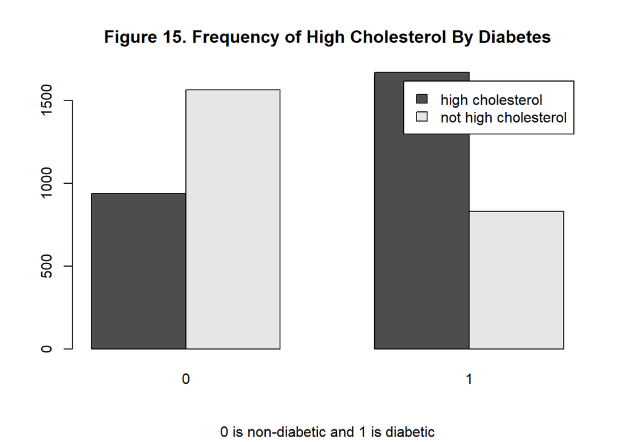

```r
tbl <- with(task3, table(HighChol, Diabetes_binary))
barplot(tbl, beside = TRUE, legend = TRUE, main = "Figure 15. Frequency of High Cholesterol By Diabetes", sub = "0 is non-diabetic and 1 is diabetic")
```

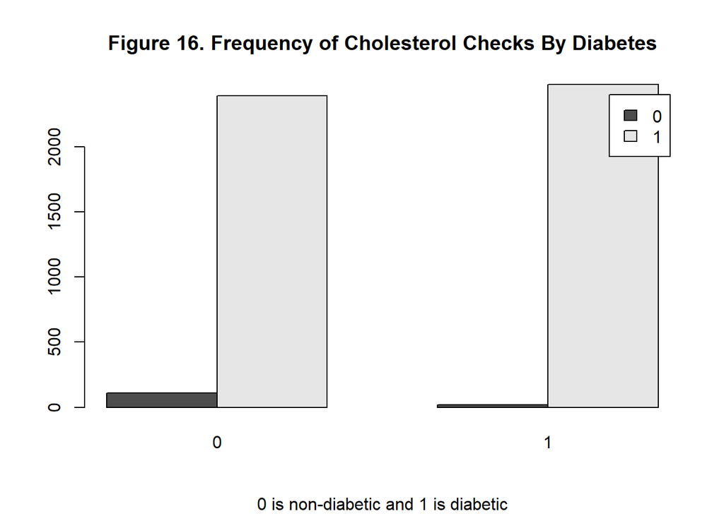

```r
tbl <- with(task3, table(CholCheck, Diabetes_binary))
barplot(tbl, beside = TRUE, legend = TRUE, main = "Figure 16. Frequency of Cholesterol Checks By Diabetes", sub = "0 is non-diabetic and 1 is diabetic")
```

Even though I originally included sex as a potential factor for diabetes, after looking at figure 13 I decided it best to get rid of it as a factor even though being a male significantly increase your chances of having diabetes according to the summary of the model. I also decided to get rid of the cholesterol check by diabetes as it seems to show little difference between the people that have diabetes or don’t. When it was removed the success rate barely decreased so I ended up getting rid of them as a predictors for diabetes.

## Model

```r
set.seed(143)
trainingRows <- sample( 1:nrow(task3), size = floor(0.80*nrow(task3)),replace=FALSE)
training <- task3[trainingRows, ]
testing <- task3[-trainingRows, ]



training_model <- glm(Diabetes_binary ~ age + GeneralHealth + HighBP + HighChol + BMI + HeartDiseaseorAttack , data=training, family = "binomial")
#summary(training_model)

testing_model <- glm(Diabetes_binary ~ age + GeneralHealth + HighBP + HighChol + BMI + HeartDiseaseorAttack , data=testing, family = "binomial")
#summary(testing_model)
```

Training Model: $oddsDiabetic = e^{-4.57 + 0.38(age30-39) + 1.27(age40-49) + 1.36(age50-59) + 1.85(age60-69) + 2.10(age70-79) + 1.98(age80+)...}$

Continued: $oddsDiabetic = e^{ 2.09(healthFair) + 1.60(healthGood) + 1.99(healthPoor) + 0.84(healthVeryGood) - 0.73(notHighBP) - 0.55(notHighChol)... }$

ContinuedAgain: $oddsDiabetic = e^{0.072(BMI) + 0.41(heartDiseaseOrAttack)}$

Testing Model: $oddsDiabetic = e^{-4.27 + 0.15(age30-39) -0.50(age40-49) + 0.67(age50-59) + 1.09(age60-69) + 0.95(age70-79) + 1.04(age80+)...}$

Continued: $oddsDiabetic = e^{ 2.10(healthFair) + 1.73(healthGood) + 1.89(healthPoor) + 0.99(healthVeryGood) - 0.75(notHighBP) - 0.68(notHighChol)... }$

ContinuedAgain: $oddsDiabetic = e^{0.087(BMI) + 0.46(heartDiseaseOrAttack)}$

## Confusion Matrix and Success Rates

### Training

```r
trainingWPredictions <- training %>%
  mutate(
    training_predictions = predict.glm(training_model, newdata = training, type = "response"),
    predicted_class = ifelse(training_predictions < 0.45, "Predicted does not have diabetes", "Predicted has diabetes"),
    outcome_class = ifelse(Diabetes_binary == "0", "No", "Yes")
  )

confusion_matrix <- table(trainingWPredictions$outcome_class, trainingWPredictions$predicted_class)
kable(confusion_matrix)
```

|  | Predicted does not have diabetes | Predicted has diabetes |
| --- | --- | --- |
| No | 1298 | 674 |
| Yes | 366 | 1662 |

```r
training_success_rate = sum(diag(confusion_matrix)) / nrow(training)
training_error_rate <- 1 - training_success_rate

falsePositive = 674 / (1298 + 674 + 366 + 1662)
falseNegative = 366 / (1298 + 674 + 366 + 1662)
```

Success rate is 0.74 while the error rate is 0.26. The false positive rate is 0.1685 while the false negative rate is 0.0915. The threshold was changed to decrease the number of false negatives because giving someone a false negative when they really do have diabetes could be fatal. As stated before, changing the threshold slightly hurts the success rate but is necessary in this case.

### Testing

```r
testingWPredictions <- testing %>%
  mutate(
    testing_predictions = predict.glm(testing_model, newdata = testing, type = "response"),
    predicted_class = ifelse(testing_predictions < 0.45, "Predicted does not have diabetes", "Predicted has diabetes"),
    outcome_class = ifelse(Diabetes_binary == "0", "No", "Yes")
  )

confusion_matrix <- table(testingWPredictions$outcome_class, testingWPredictions$predicted_class)
kable(confusion_matrix)
```

|  | Predicted does not have diabetes | Predicted has diabetes |
| --- | --- | --- |
| No | 363 | 165 |
| Yes | 100 | 372 |

```r
testing_success_rate = sum(diag(confusion_matrix)) / nrow(testing)
testing_error_rate = 1 - testing_success_rate

falsePositive = 165 / (392 + 136 + 126 + 346)
falseNegative = 100 / (392 + 136 + 126 + 346)
```

Success rate is 0.735 while the error rate is 0.265. The false positive rate is 0.165 while the false negative rate is 0.1. The threshold was changed to decrease the number of false negatives because giving someone a false negative when they really do have diabetes could be fatal. As stated before, changing the threshold slightly hurts the success rate but is necessary in this case.

## Final Model

The final model uses the same variables that were tested with the training and testing split, but this model is made with the entire data set rather than just the training split so the coefficients will be slightly different.

```r
all_model <- glm(Diabetes_binary ~ age + GeneralHealth + HighBP + HighChol + BMI + HeartDiseaseorAttack , data=task3, family = "binomial")

#summary(all_model)
```

Final Model: $oddsDiabetic = e^{-4.50 + 0.34(age30-39) + 0.98(age40-49) + 1.24(age50-59) + 1.72(age60-69) + 1.89(age70-79) + 1.81(age80+)...}$

Continued: $oddsDiabetic = e^{ 2.08(healthFair) + 1.61(healthGood) + 1.96(healthPoor) + 0.86(healthVeryGood) - 0.73(notHighBP) - 0.57(notHighChol)... }$

ContinuedAgain: $oddsDiabetic = e^{0.075(BMI) + 0.42(heartDiseaseOrAttack)}$

## Success Rate and Hypothesis Test

```r
library(kableExtra)
all_model <- glm(Diabetes_binary ~ age + GeneralHealth + HighBP + HighChol + BMI + HeartDiseaseorAttack , data=task3, family = "binomial")

allWPredictions <- task3 %>%
  mutate(
    all_predictions = predict.glm(all_model, newdata = task3, type = "response"),
    predicted_class = ifelse(all_predictions < 0.45, "Predicted does not have diabetes", "Predicted has diabetes"),
    outcome_class = ifelse(Diabetes_binary == "0", "No", "Yes")
  )

confusion_matrix <- table(allWPredictions$outcome_class, allWPredictions$predicted_class)
kable(confusion_matrix)
```

|  | Predicted does not have diabetes | Predicted has diabetes |
| --- | --- | --- |
| No | 1653 | 847 |
| Yes | 469 | 2031 |

```r
class_success_rate = sum(diag(confusion_matrix)) / nrow(task3)
class_error_rate = 1 - class_success_rate

falseNegative = 459 / (1653 + 469 + 847 + 2031)
falsePositive = 847 / (1653 + 469 + 847 + 2031)

SE <- sqrt((0.5*(1 - 0.5)) / nrow(task3))
testStatistic = (0.7375 - 0.5) / SE
pValue = 1 - pnorm(testStatistic)
#z = 33.588
```

### P Value

In this data set 50% of people do not have diabetes so our success rate has to be statistically more significant than that value.

The test statistic is 33.5875721 while the p - value is 0. Our model with a success rate of 73.68% is statistically more significant than the null hypothesis of 50.0% according to the p - value reported.

# Ethics

When mining sensitive data like this we must take into account the ethical implications. First and foremost, “Patient information is required by law to be gathered only with complete consent by the patient. And such information can be accessed or used by research companies only after many levels of security checks”(1). By assuming this data was gathered legally, we are technically not doing anything wrong. However, this information can be used for the wrong reasons. If it is strictly for the purpose of treating people that have diabetes than analyzing this data has altruistic means. This form of analysis could be used for illnesses other than diabetes.

“Employers are not covered by HIPAA. Even if they pay for your insurance or medical care out of pocket, HIPAA does not allow your employer to access your medical records or insurance claims because it could lead to discrimination”(3). But if an employer asks for information that they could use to predict whether you had an illness or not you may be coerced into giving that information. Theoretically, this could be an issue because the employer could choose not to hire someone if they were more likely to have an illness even though they should not be able to know if you have that illness or not.

# Conclusion

This paper shows that different data set can provide varying and valid models for logistic regression. The reason for the different factors being important in one model and not in another is simply because many of the factors were not present in all three data sets. We saw that age, which was in every data set, was important in all of the data sets. The mode with the best success rate was the second model with a rate of 84.77% but the model that was the most statistically significant was the the third one with a z score of 33.5875721.

# Bibliography

1. Erick, P. (2020, February 10). Ethical implications of data mining! Sollers College. Retrieved December 3, 2022, from https://sollers.edu/ethical-implications-of-data-mining/
2. Gary-JayBourley. Differences between type 1 and type 2 diabetes. Diabetes UK. Retrieved December 3, 2022, from https://www.diabetes.org.uk/diabetes-the-basics/differences-between-type-1-and-type-2-diabetes#:~:text=The%20main%20difference%20between%20the,producing%20cells%20in%20your%20pancreas.
3. Torrey, T. (2022, March 11). How private are your medical records? Verywell Health. Retrieved December 3, 2022, from https://www.verywellhealth.com/who-has-access-to-your-medical-records-2615502